# too many categories, table is better

# too many categories, table is better

```r
topstates <- l  %>% group_by(BorrowerState)  %>% summarise(count=n()) %>% arrange(desc(count)) %>% top_n(5)
```

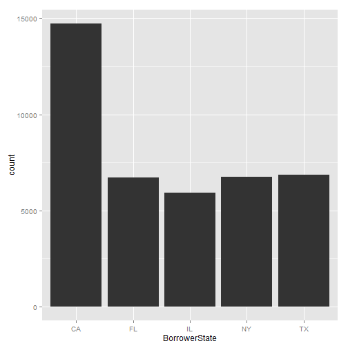

```r
ggplot(data=topstates, aes(x=BorrowerState, y=count)) +geom_bar(stat='identity')
```

# not much clarity from this chart, top is other, professional

```r
topoccupation <- l  %>% group_by(Occupation)  %>% summarise(count=n()) %>% arrange(desc(count)) %>% top_n(5)
```

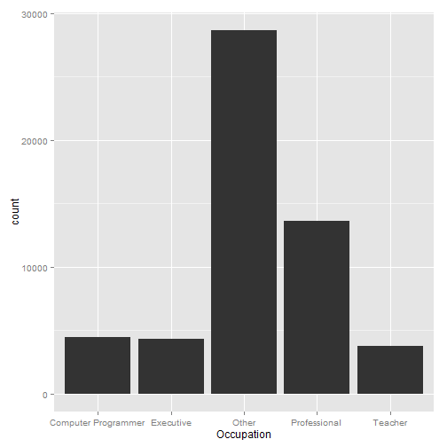

```r
ggplot(data=topoccupation, aes(x=Occupation, y=count)) +geom_bar(stat='identity')
```

#mainly employed #half half

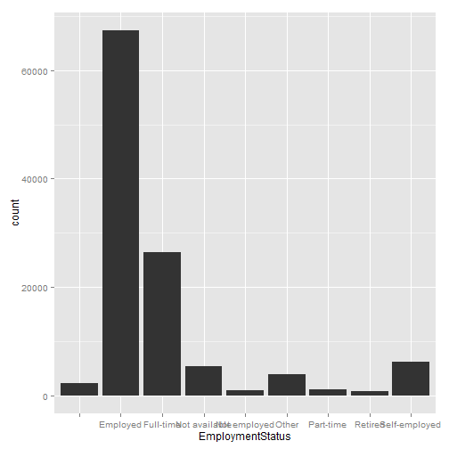

```r
ggplot(data=l, aes(x=EmploymentStatus)) +geom_bar()
```

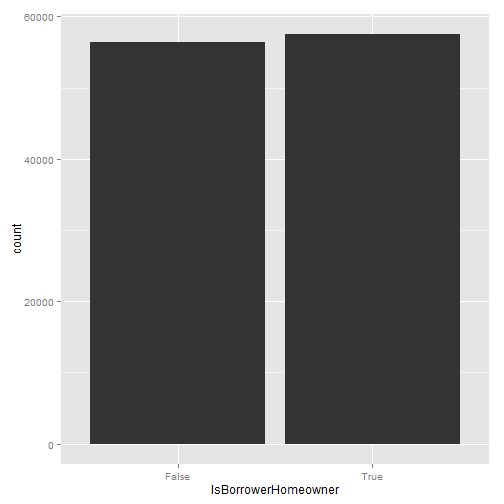

```r
ggplot(data=l, aes(x=IsBorrowerHomeowner)) +geom_bar()
```

# mostly in middle range from 25k-75k

# majority 3 year loans

```r
summary(l$IncomeRange)
```

```
##             $0      $1-24,999      $100,000+ $25,000-49,999 $50,000-74,999
##            621           7274          17337          32192          31050
## $75,000-99,999  Not displayed   Not employed
##          16916           7741            806
```

```r
summary(as.factor(l$Term))
```

```
##    12    36    60
##  1614 87778 24545
```

# mostly 1 - debt consolidation

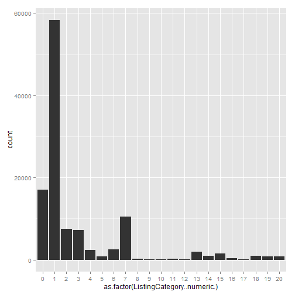

```r
ggplot(data=l, aes(x=as.factor(ListingCategory..numeric.))) +geom_bar()
```

# most completed, current

```r
table(l$LoanStatus)
```

```
##
##              Cancelled             Chargedoff              Completed
##                      5                  11992                  38074
##                Current              Defaulted FinalPaymentInProgress
##                  56576                   5018                    205
##   Past Due (>120 days)   Past Due (1-15 days)  Past Due (16-30 days)
##                     16                    806                    265
##  Past Due (31-60 days)  Past Due (61-90 days) Past Due (91-120 days)
##                    363                    313                    304
```

#bivarate analysis

#correlation matrix of continuous variables

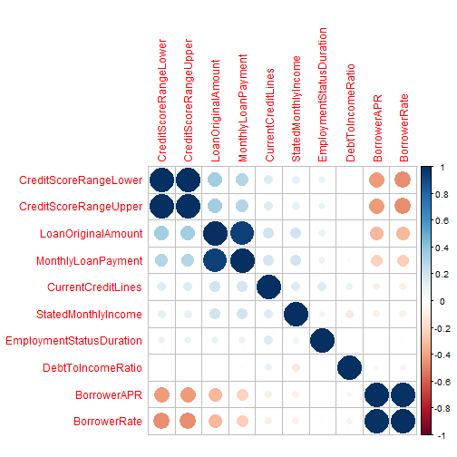

```r
#install.packages('corrplot')
library(corrplot)
loanscontinuous <- select(loans, EmploymentStatusDuration,
CreditScoreRangeLower,
CreditScoreRangeUpper,
CurrentCreditLines,
DebtToIncomeRatio,
StatedMonthlyIncome,
BorrowerAPR,
BorrowerRate,
LoanOriginalAmount,
MonthlyLoanPayment)

df<- data.frame((sapply(loanscontinuous,c)))

M <-cor(df, use="pairwise.complete.obs")
p = M
p[is.na(M)]=0.2
p[is.na(M)==F]=0
M[is.na(M)]=0
#corrplot(M, method="circle", is.corr=T, p.mat=p, sig.level=0.1, order = "FPC")
corrplot(M, order = "FPC")
```

#####scatterplots

# large concentration of borrowers < $5000 and < 100 months of employment

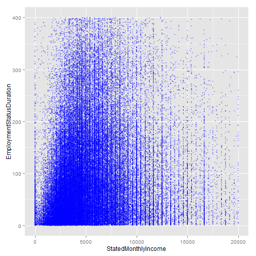

```r
ggplot(data=l, aes(x=StatedMonthlyIncome, y=EmploymentStatusDuration)) +geom_point(alpha=0.3, size= 0.5, position='jitter', color='blue') +xlim(0, 20000) + ylim(0, 400)
```

# large concentration of borrowers < $5000 and < .5 d/i ratio

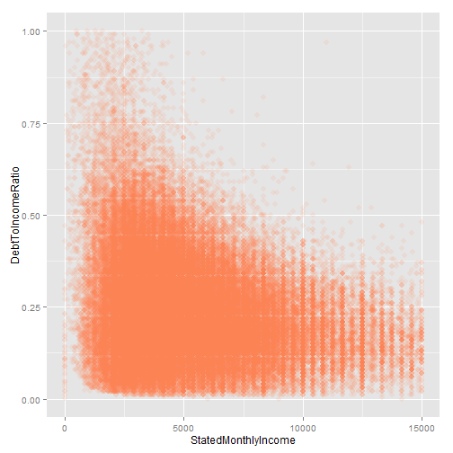

```r
ggplot(data=l, aes(x=StatedMonthlyIncome, y=DebtToIncomeRatio)) +geom_point(alpha=0.1, size=3, position='jitter',color='coral') +xlim(0, 15000) + ylim(0, 1)
```

# concentrated around 640-740 and under 0.5

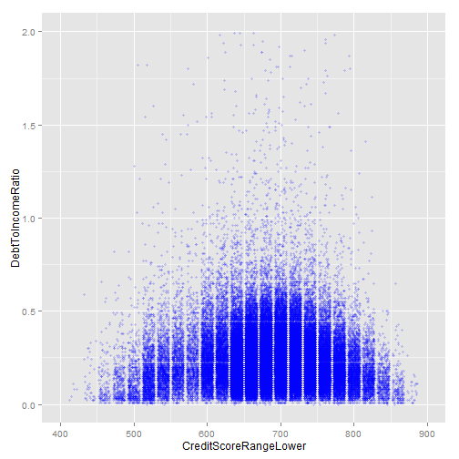

```r
ggplot(data=l, aes(x=CreditScoreRangeLower, y= DebtToIncomeRatio)) +geom_point(alpha=0.2, size=1.5, position='jitter', color='blue') +ylim(0, 2) +xlim(400, 900)
```

#slightly offset 20 points to the right

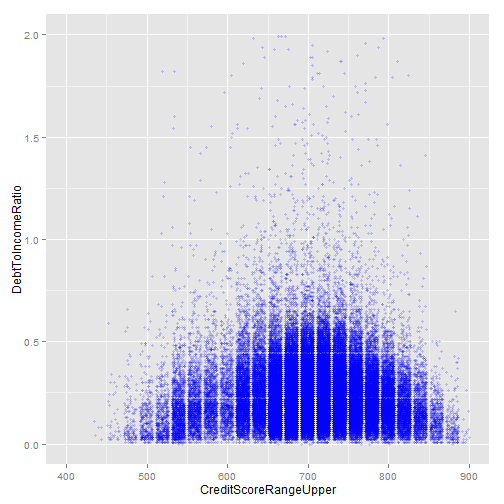

```r
ggplot(data=l, aes(x=CreditScoreRangeUpper, y= DebtToIncomeRatio)) +geom_point(alpha=0.2, size=1.5, position='jitter', color='blue') +ylim(0, 2) +xlim(400, 900)
```

#interest rate vs monthly payments higher the payments lower the interest rate

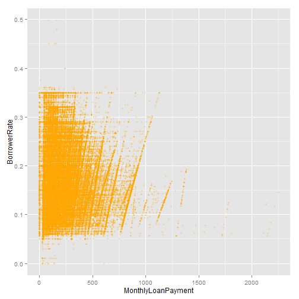

```r
ggplot(data=l, aes(x=MonthlyLoanPayment, y=BorrowerRate )) +geom_point(alpha=0.3, size=1.5, position='jitter', color='orange')
```

#interest rate vs loan amount

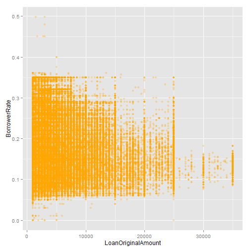

```r
ggplot(data=l, aes(x=LoanOriginalAmount, y=BorrowerRate )) +geom_point(alpha=0.3, size=2, position='jitter', color='orange')
```

# looks like people with better credit score have larger dispersion of loan amount

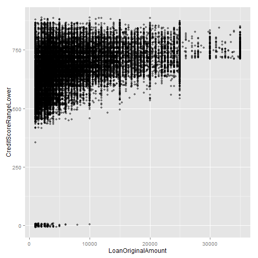

```r
ggplot(data=l, aes(x=LoanOriginalAmount, y=CreditScoreRangeLower )) +geom_point(alpha=0.5, size=2, position='jitter')
```

# loans mostly <1000 with statedmonthly income of <10000

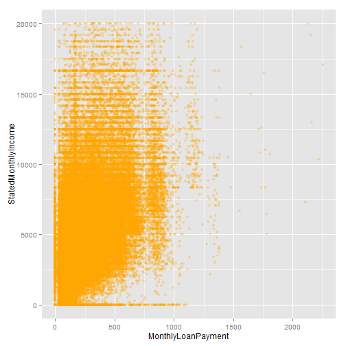

```r
ggplot(data=l, aes(x=MonthlyLoanPayment, y=StatedMonthlyIncome )) +geom_point(alpha=0.3, size=2, position='jitter', color='orange') +ylim(0, 20000)
```

# looks like there's a peak around 15 credit lines at around 200 (16.6 years) months of employment then trails off

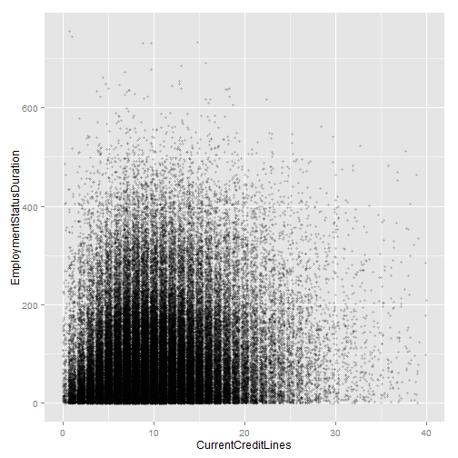

```r
ggplot(data=l, aes(x=CurrentCreditLines, y=EmploymentStatusDuration )) +geom_point(alpha=0.2, size=1.5, position='jitter') +xlim(0, 40)
```

#created variable estimate of total debt at inception of loan

```r
l$TotalDebt<- l$DebtToIncomeRatio * l$StatedMonthlyIncome
summary(l$TotalDebt)
```

```
##     Min.  1st Qu.   Median     Mean  3rd Qu.     Max.     NA's
##      0.0    637.5   1062.0   1225.0   1622.0 171000.0     8554
```

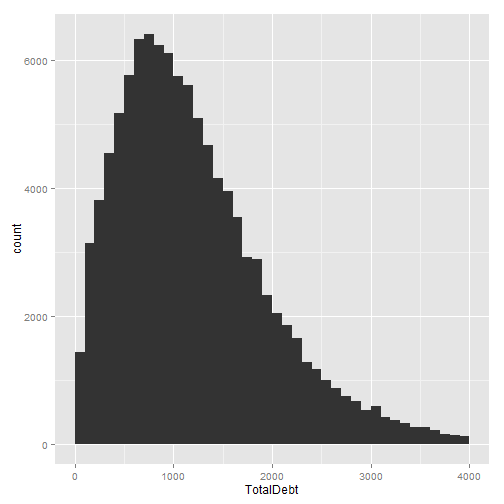

```r
ggplot(data=subset(l, !is.na(TotalDebt)), aes(x=TotalDebt)) +geom_bar(binwidth=100) + xlim(0, 4000)
```

#99% 3900

```r
with(subset(l, !is.na(TotalDebt)), quantile(TotalDebt, 0.99))
```

```
##  99%
## 3900
```

#####boxplots

```r
by(l$LoanOriginalAmount, l$LoanYear,summary)
```

```
## l$LoanYear: 2005
##    Min. 1st Qu.  Median    Mean 3rd Qu.    Max.
##    1000    1500    3000    3577    4150   15000
## --------------------------------------------------------
## l$LoanYear: 2006
##    Min. 1st Qu.  Median    Mean 3rd Qu.    Max.
##    1000    2000    3001    4763    5590   25000
## --------------------------------------------------------
## l$LoanYear: 2007
##    Min. 1st Qu.  Median    Mean 3rd Qu.    Max.
##    1000    3000    5000    7050    9500   25000
## --------------------------------------------------------
## l$LoanYear: 2008
##    Min. 1st Qu.  Median    Mean 3rd Qu.    Max.
##    1000    2200    4500    6022    7500   25000
## --------------------------------------------------------
## l$LoanYear: 2009
##    Min. 1st Qu.  Median    Mean 3rd Qu.    Max.
##    1000    1500    3000    4355    5320   25000
## --------------------------------------------------------
## l$LoanYear: 2010
##    Min. 1st Qu.  Median    Mean 3rd Qu.    Max.
##    1000    2000    3800    4767    6000   25000
## --------------------------------------------------------
## l$LoanYear: 2011
##    Min. 1st Qu.  Median    Mean 3rd Qu.    Max.
##    2000    3800    5500    6692    8361   25000
## --------------------------------------------------------
## l$LoanYear: 2012
##    Min. 1st Qu.  Median    Mean 3rd Qu.    Max.
##    2000    4000    5000    7834   11500   25000
## --------------------------------------------------------
## l$LoanYear: 2013
##    Min. 1st Qu.  Median    Mean 3rd Qu.    Max.
##    2000    4000   10000   10550   15000   35000
## --------------------------------------------------------
## l$LoanYear: 2014
##    Min. 1st Qu.  Median    Mean 3rd Qu.    Max.
##    2000    6500   10000   11910   15000   35000
```

#dips in 08/09 and rebounds in 13/14

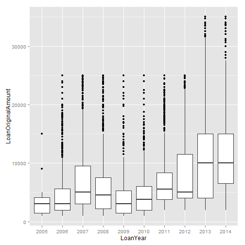

```r
ggplot(data=l, aes(x=LoanYear,y=LoanOriginalAmount))+ geom_boxplot()
```